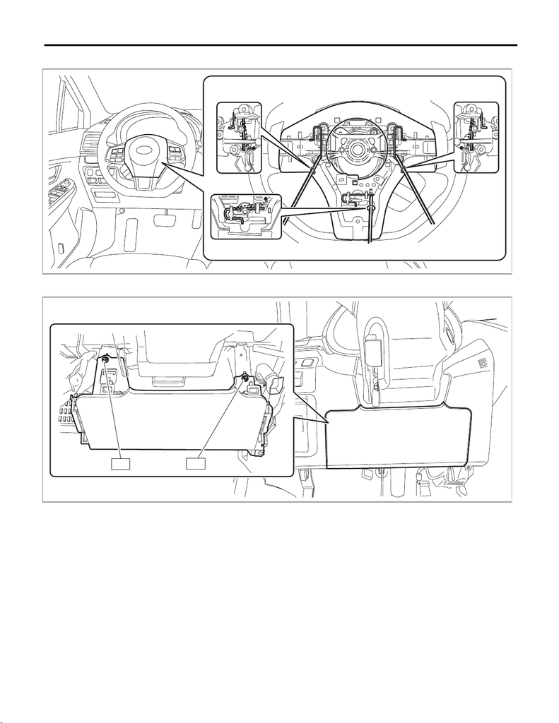

AB-3

General Description

AIRBAG SYSTEM

1. DRIVER’S AIRBAG MODULE

2. KNEE AIRBAG MODULE

Tightening torque:

7.5 N·m (0.8 kgf-m, 5.5 ft-lb)

AB-03527

AB-02936

T

T

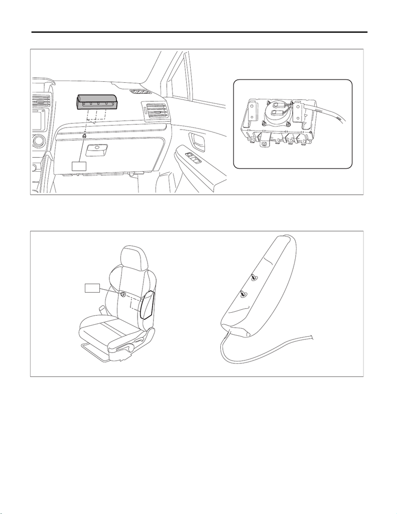

AB-4

General Description

AIRBAG SYSTEM

3. PASSENGER’S AIRBAG MODULE

Tightening torque:

7.5 N·m (0.8 kgf-m, 5.5 ft-lb)

4. SIDE AIRBAG MODULE

Tightening torque:

6 N·m (0.6 kgf-m, 4.4 ft-lb)

AB-02919

T

AB-03507

T

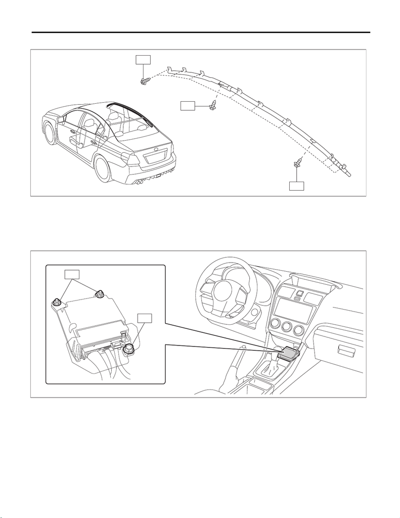

AB-5

General Description

AIRBAG SYSTEM

5. CURTAIN AIRBAG MODULE

Tightening torque:

7.5 N·m (0.8 kgf-m, 5.5 ft-lb)

6. AIRBAG CONTROL MODULE

CAUTION:

Do not reuse mounting bolts and nuts.

Tightening torque:

25 N·m (2.5 kgf-m, 18.4 ft-lb)

AB-03508

T

T

T

AB-03509

T

T

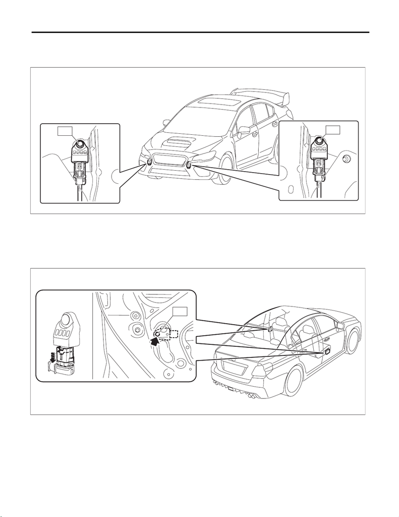

AB-6

General Description

AIRBAG SYSTEM

7. FRONT SUB SENSOR

CAUTION:

Do not reuse mounting bolts and nuts.

Tightening torque:

13 N·m (1.3 kgf-m, 9.6 ft-lb)

8. FRONT DOOR IMPACT SENSOR

CAUTION:

Do not reuse mounting bolts and nuts.

Tightening torque:

7.5 N·m (0.8 kgf-m, 5.5 ft-lb)

AB-03547

T

T

AB-03518

T

[figure not shown]

AB-7

General Description

AIRBAG SYSTEM

9. SIDE AIRBAG SENSOR

CAUTION:

Do not reuse mounting bolts and nuts.

Tightening torque:

7.5 N·m (0.8 kgf-m, 5.5 ft-lb)

10.CURTAIN AIRBAG SENSOR

CAUTION:

Do not reuse mounting bolts and nuts.

Tightening torque:

7.5 N·m (0.8 kgf-m, 5.5 ft-lb)

AB-03519

T

AB-03521

T

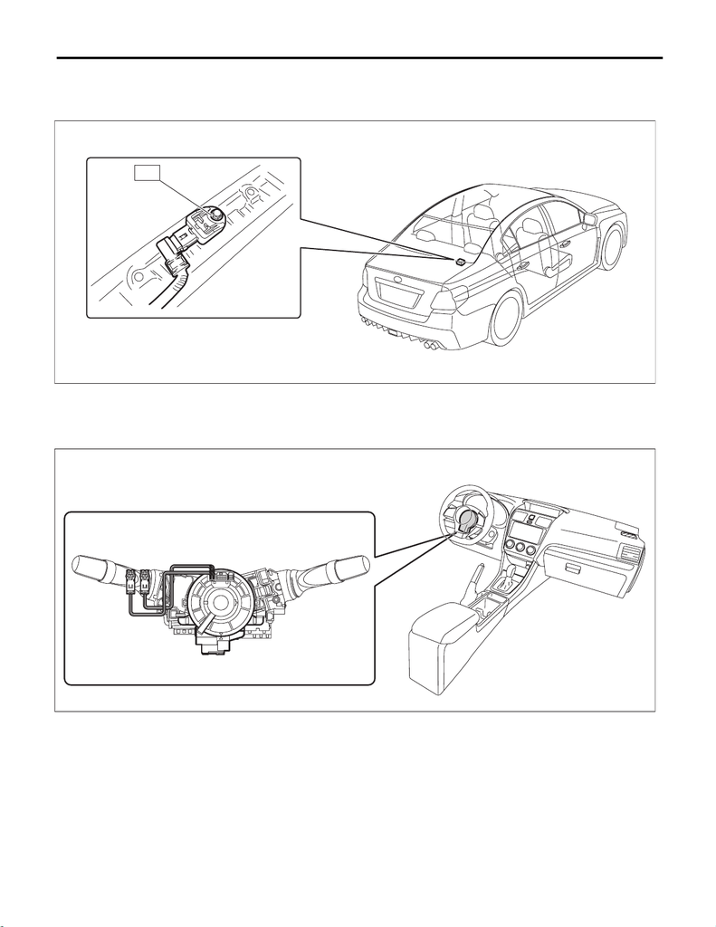

AB-8

General Description

AIRBAG SYSTEM

11.SATELLITE SAFING SENSOR

CAUTION:

Do not reuse mounting bolts and nuts.

Tightening torque:

7.5 N·m (0.8 kgf-m, 5.5 ft-lb)

12.STEERING ROLL CONNECTOR

AB-03525

T

AB-03526

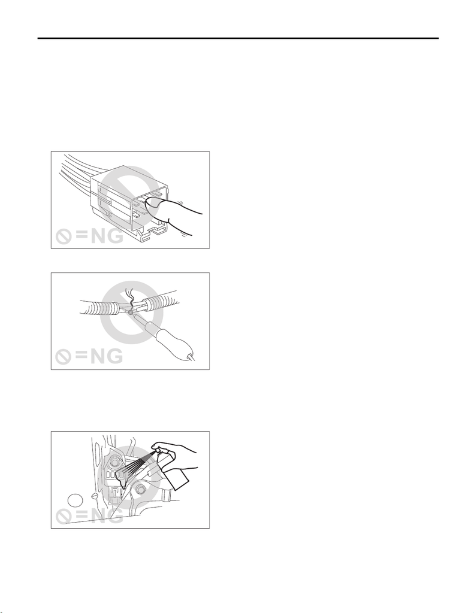

AB-9

General Description

AIRBAG SYSTEM

B: CAUTION

1. BEFORE STARTING ALL WORKS

• The airbag system is fitted with a backup power supply. After disconnecting the battery ground cable, the

airbag may operate if you do not wait for 60 seconds or more before starting the service of airbag system.

• When servicing a vehicle, be sure to turn the ignition switch to OFF, disconnect the ground cable from bat-

tery, and wait for 60 seconds or more before starting work.

• If the airbag warning light illuminates, check or repair the vehicle immediately to prevent it from airbag sys-

tem malfunction.

• Do not allow water or oil to come in contact with the connector terminals. Also, do not touch the connector

terminals directly.

• If damage, open circuit or rust is found on airbag system wiring harness, do not repair the harness. Always

replace the faulty harness with a new genuine part.

• When painting or performing sheet metal work on the front part of the vehicle, including the front wheel

apron, front fender and radiator panel side, remove the front sub sensors and wiring harness of airbag sys-

tem.

• When painting or performing sheet metal work on the side of the vehicle, including the side sill, center pillar

and front and rear doors, remove the front door impact sensor, side airbag sensors, curtain airbag sensor,

satellite safing sensor and wiring harness of the airbag system.

• When attaching the steering wheel and steering roll connector, be sure to adjust the steering roll connec-

tor.

AB-03514

AB-03515

AB-03516

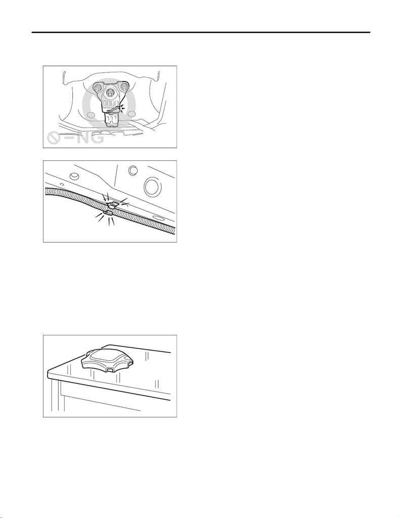

AB-10

General Description

AIRBAG SYSTEM

2. BEFORE STARTING PARTS REPLACEMENT

• If airbag sensors, airbag module, airbag control module, pretensioners, harnesses, or the cover - satellite

safing are deformed or damaged, replace with new parts.

• Install the wiring harness securely with the specified clips to avoid interference or tangled with other parts.

• Do not use the airbag or pretensioner parts from other vehicles. Always replace the defective parts with

new parts.

• Never reuse any activated airbag module and pretensioner.

• Do not discard undeployed airbag or pretensioner.

• When airbag control module, front sub sensor, front door impact sensor, side airbag sensor, curtain airbag

sensor and satellite safing sensor are removed, do not reuse the bolts and nuts of them. Always replace with

the specified new bolts and nuts.

• When attaching the steering wheel and steering roll connector, be sure to adjust the steering roll connec-

tor.

• After removing each parts of the airbag system, keep them with the pad side facing upward on a dry, clean

and flat surface away from heat, light sources, moisture and dust.

AB-03517

AB-00125

AB-00056

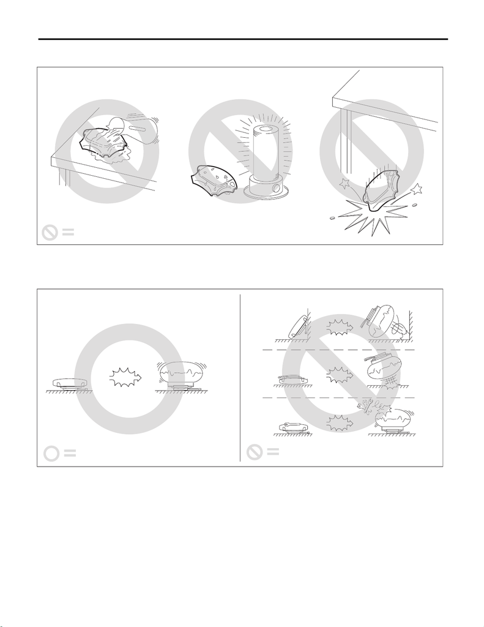

AB-11

General Description

AIRBAG SYSTEM

• Do not drop any airbag component, store them under high temperature of 85°C (185°F) or more, or let wa-

ter, oil or grease get on them; the internal parts may be damaged or the reliability may be greatly lowered.

• When storing a removed airbag module, do not place it with the pad side facing downward. Do not place

any objects on the airbag module. Do not pile up the airbag module. If the pad of the airbag module is in con-

tact with other objects, it may cause a serious accident if the airbag accidentally operates.

• Driver’s airbag module

AB-02315

NG

=

AB-02316

N

G

=

O

K

=

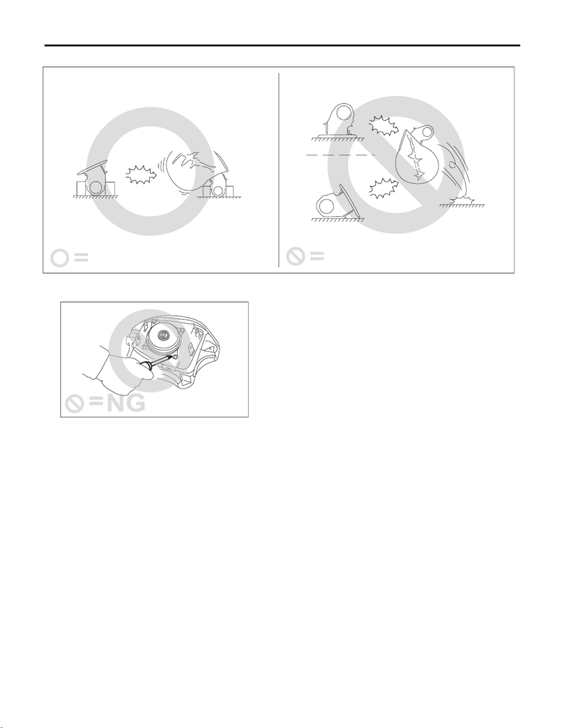

AB-12

General Description

AIRBAG SYSTEM

• Passenger’s airbag module and side airbag module

• Do not disassemble driver’s airbag module, knee airbag module, passenger’s airbag module, side airbag

module, curtain airbag module or pretensioner.

• The removed front seat with airbag module must be kept at least 200 mm (8 in) away from walls and other

objects.

AB-02317

N

G

=

O

K

=

AB-03520

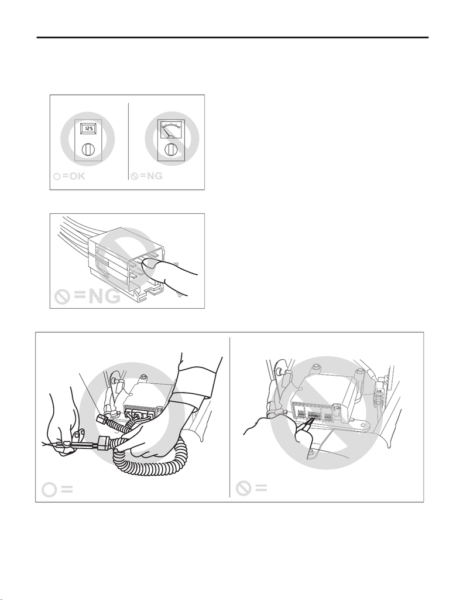

AB-13

General Description

AIRBAG SYSTEM

3. BEFORE STARTING TROUBLESHOOTING

• Even if any part must be replaced as the result of troubleshooting, do not use an airbag part or pretension-

er part from other vehicles. Always replace the defective parts with new parts.

• When checking the airbag system, be sure to use a digital circuit tester. Use of an analog circuit tester may

cause the airbag to activate erroneously due to a minimal current inside tester.

• Do not allow water or oil to come in contact with the connector terminals. Also, do not touch the connector

terminals directly.

• When checking, use a test harness (1). Damage to connector terminal causes malfunction. Do not directly

put the tester probe on airbag connector terminal.

AB-03522

AB-03514

AB-02321

N

G

=

O

K

=

(1)

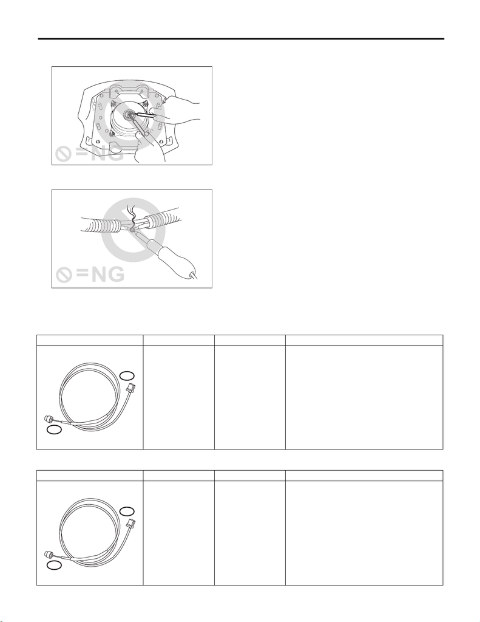

AB-14

General Description

AIRBAG SYSTEM

• Do not check continuity of the driver’s airbag module, knee airbag module, passenger’s airbag module,

side airbag module, curtain airbag module or pretensioner.

• If damage, open circuit or rust is found on airbag system wiring harness, do not repair the harness. Always

replace the faulty harness with a new genuine part.

C: PREPARATION TOOL

1. SPECIAL TOOL

• TEST HARNESS N

• TEST HARNESS Q

AB-03523

AB-03515

ILLUSTRATION TOOL NUMBER DESCRIPTION REMARKS

98299SA000 TEST HARNESS N Used for unit inspection of steering roll connec-

tor.

ILLUSTRATION TOOL NUMBER DESCRIPTION REMARKS

98299SA040 TEST HARNESS Q Used for unit inspection of steering roll connec-

tor.

2N

1N

ST98299SA000

2Q

1Q

ST98299SA040

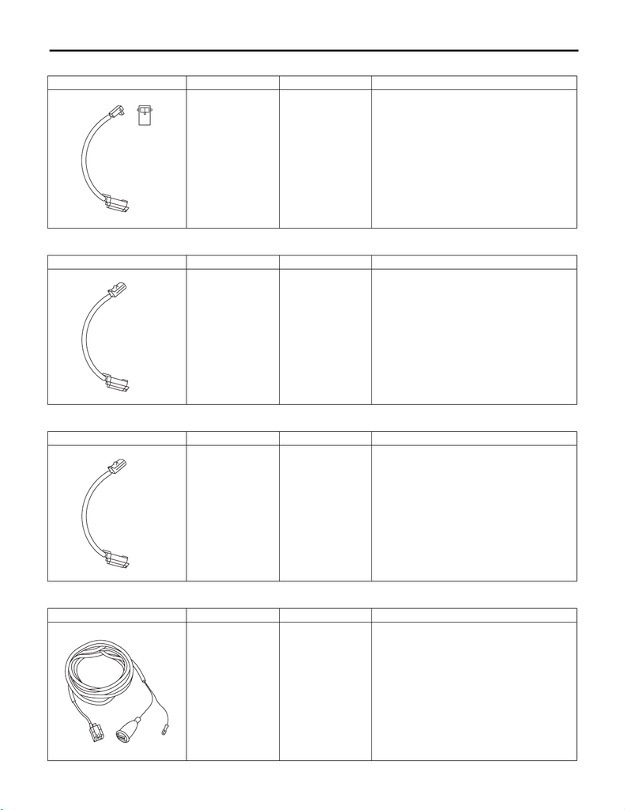

AB-15

General Description

AIRBAG SYSTEM

• TEST HARNESS ADAPTER D

• TEST HARNESS ADAPTER AM

• TEST HARNESS ADAPTER K

• AIRBAG DEPLOYMENT TOOL

ILLUSTRATION TOOL NUMBER DESCRIPTION REMARKS

98299SA010 TEST HARNESS

ADAPTER D

• Used for operation process of knee airbag

module.

• Used for operation process of curtain airbag

module.

• Used together with AIRBAG DEPLOYMENT

TOOL. (98299PA030)

ILLUSTRATION TOOL NUMBER DESCRIPTION REMARKS

98299FJ000 TEST HARNESS

ADAPTER AM

• Used for operation process of passenger’s air-

bag module.

• Used together with AIRBAG DEPLOYMENT

TOOL. (98299PA030)

ILLUSTRATION TOOL NUMBER DESCRIPTION REMARKS

98299FG010 TEST HARNESS

ADAPTER K

• Used for operation process of side airbag

module.

• Used together with AIRBAG DEPLOYMENT

TOOL. (98299PA030)

ILLUSTRATION TOOL NUMBER DESCRIPTION REMARKS

98299PA030 AIRBAG DEPLOY-

MENT TOOL

• Used for operation process of airbag module.

• Used together with each test harness adapter.

ST98299SA010

ST98299FJ000

ST98299FG010

ST98299PA030

[figure not shown]

AB-16

General Description

AIRBAG SYSTEM

2. GENERAL TOOL

TOOL NAME REMARKS

Steering wheel puller Used for removing and installing the steering wheel.

TORX

®

T40 Used for removing and installing the beam COMPL - steering.

Circuit tester Used for measuring resistance and voltage.